# Machine Learning Regression

Evan Carey, created for BH Analytics

# Objectives

- Understand machine learning versus traditional approaches to inference
- Overview of different algorithms

# Overview

The purpose of this section is to go over machine learning, specifically regression, in the context of R. We will include some general concepts of machine learning as well as the specifics of a few different regression algorithms. For further reading, I highly recommend the free ebook titled ‘Introduction to Statistical Learning’ by Gareth James. A quick web search should find this book near the top of the search results. For even more in-depth coverage of machine learning algorithms, I recommend the book ‘Elements of Statistical Learning’ by Trevor Hastie (also free online!).

# Machine Learning

- Machine learning is the science of programming algorithms to learn from data.
- Machine learning is focused on prediction - Predictive Modeling
- Machine learning uses finite sample properties to optimize models.
- Traditional statistics focuses on process inference - statistical inference
- Traditional statistics often use asymptotic properties to make inference
- In practice, there is much overlap between the disciplines…

# Machine Learning Terminology

- Target: what I want to predict
- Inputs: The variables I am using to predict the target
- Samples: The rows of the dataframe
- Unsupervised Learning: Algorithms without a target
  - Clustering
  - Dimensionality Reduction
- Supervised Learning: Algorithms using a target
  - Classification: Target is discrete
  - Regression: Target is continuous

# Variance, Bias, and Over-fitting

- Variance refers to how variables your estimates are
- Bias refers to how accurate your estimates are
- Think of shooting arrows at a target: Low bias means on average, you get close to the center. Low variance means your arrows are all close together
- There is often a trade off between bias and variance.
- Over-fitting our data: too many attempts at fitting leads to a great fit…but maybe only for this data?

# How to Avoid Over-fitting?

- Incorporate your topical knowledge when selecting features
- The best model fits come from careful feature selection rather than automated decisions
- Remove redundant variables (highly correlated)
- Sensor values in your data you know to be inaccurate (Careful data cleaning)
- Identify structure in your data and use it appropriately
  - Do you have clusters?
  - Repeated measures over time?

# Prediction and the Data Generating Process

- There is a key concept you must understand before we move forward.
- The goal of implementing a machine learning classification approach is to describe the **data generating process**, so that we can create good predictions for future realizations of data from that data generating process.
- However, we can’t see the data generating process! All we can see is past samples from the data generating process (data we have already observed)
- So, we will try to use the data we have observed to accurately describe the data generating process.
- Here is the important distinction:
  - I am **not** interested in accurately describing the data I have already observed!
  - I am interested in using that data to accurately describe the data generating process.
  - So we have to be careful to not over fit the data we can see, at the expense of having a good model for future data (ie, a good model for the data generating process)
  - We will come back to this concept later in the lecture.

# Regression Overview

- Let’s focus on regression and learn more about the machine learning approach to statistical learning.
- In the case where our outcome (target) variable is continuous, we can use regression algorithms to predict the mean outcome.
- We are interested in predicting the mean value of the outcome for a given unit. We sometimes called this the ‘expected value’.
- Some examples include:
  - Costs (what is the average cost per hospitalization for certain patients?)
  - Home values (what is the average home value, considering some traits about the home)
  - Rainfall (What is the average expected amount of rainfall?)
  - Customer wait times (What is the average expected wait time for a call center?)
  - Income (What is the average amount of income someone makes?)
- Can you think of any more examples of continuous outcomes?

# Motivating Dataset: Boston Housing Data

- We will explore regression in the context of the Boston housing data from the MASS package.
- First, import the data.
- Check the help page out for the data
- Perform an initial review of the data

```r
library(MASS)
library(Hmisc)

## Import Dataset
data(Boston)
## Review Data
# ?Boston
head(Boston)
```

```
##      crim zn indus chas   nox    rm  age    dis rad tax ptratio  black lstat medv
## 1 0.00632 18  2.31    0 0.538 6.575 65.2 4.0900   1 296    15.3 396.90  4.98 24.0
## 2 0.02731  0  7.07    0 0.469 6.421 78.9 4.9671   2 242    17.8 396.90  9.14 21.6
## 3 0.02729  0  7.07    0 0.469 7.185 61.1 4.9671   2 242    17.8 392.83  4.03 34.7
## 4 0.03237  0  2.18    0 0.458 6.998 45.8 6.0622   3 222    18.7 394.63  2.94 33.4
## 5 0.06905  0  2.18    0 0.458 7.147 54.2 6.0622   3 222    18.7 396.90  5.33 36.2
## 6 0.02985  0  2.18    0 0.458 6.430 58.7 6.0622   3 222    18.7 394.12  5.21 28.7
```

```r
describe(Boston)
```

```
## Boston
##
##  14  Variables      506  Observations
## -----------------------------------------------------------------------------------------------------------------------------------------------------
## crim
##        n  missing distinct     Info     Mean      Gmd      .05      .10      .25      .50      .75      .90      .95
##      506        0      504        1    3.614    5.794  0.02791  0.03819  0.08204  0.25651  3.67708 10.75300 15.78915
##
## lowest :  0.00632  0.00906  0.01096  0.01301  0.01311, highest: 45.74610 51.13580 67.92080 73.53410 88.97620
## -----------------------------------------------------------------------------------------------------------------------------------------------------
## zn
##        n  missing distinct     Info     Mean      Gmd      .05      .10      .25      .50      .75      .90      .95
##      506        0       26    0.603    11.36    18.77      0.0      0.0      0.0      0.0     12.5     42.5     80.0
##
## lowest :   0.0  12.5  17.5  18.0  20.0, highest:  82.5  85.0  90.0  95.0 100.0
## -----------------------------------------------------------------------------------------------------------------------------------------------------
## indus
##        n  missing distinct     Info     Mean      Gmd      .05      .10      .25      .50      .75      .90      .95
##      506        0       76    0.982    11.14    7.705     2.18     2.91     5.19     9.69    18.10    19.58    21.89
##
## lowest :  0.46  0.74  1.21  1.22  1.25, highest: 18.10 19.58 21.89 25.65 27.74
## -----------------------------------------------------------------------------------------------------------------------------------------------------
## chas
##        n  missing distinct     Info      Sum     Mean      Gmd
##      506        0        2    0.193       35  0.06917    0.129
##
## -----------------------------------------------------------------------------------------------------------------------------------------------------
## nox
##        n  missing distinct     Info     Mean      Gmd      .05      .10      .25      .50      .75      .90      .95
##      506        0       81        1   0.5547   0.1295   0.4092   0.4270   0.4490   0.5380   0.6240   0.7130   0.7400
##
## lowest : 0.385 0.389 0.392 0.394 0.398, highest: 0.713 0.718 0.740 0.770 0.871
## -----------------------------------------------------------------------------------------------------------------------------------------------------
## rm
##        n  missing distinct     Info     Mean      Gmd      .05      .10      .25      .50      .75      .90      .95
##      506        0      446        1    6.285   0.7515    5.314    5.594    5.886    6.208    6.623    7.152    7.588
##
## lowest : 3.561 3.863 4.138 4.368 4.519, highest: 8.375 8.398 8.704 8.725 8.780
## -----------------------------------------------------------------------------------------------------------------------------------------------------
## age
```

[output cut: 36 more lines]

```
##
## lowest :   0.32   2.52   2.60   3.50   3.65, highest: 396.28 396.30 396.33 396.42 396.90
## -----------------------------------------------------------------------------------------------------------------------------------------------------
## lstat
##        n  missing distinct     Info     Mean      Gmd      .05      .10      .25      .50      .75      .90      .95
##      506        0      455        1    12.65    7.881    3.708    4.680    6.950   11.360   16.955   23.035   26.808
##
## lowest :  1.73  1.92  1.98  2.47  2.87, highest: 34.37 34.41 34.77 36.98 37.97
## -----------------------------------------------------------------------------------------------------------------------------------------------------
## medv
##        n  missing distinct     Info     Mean      Gmd      .05      .10      .25      .50      .75      .90      .95
##      506        0      229        1    22.53    9.778    10.20    12.75    17.02    21.20    25.00    34.80    43.40
##
## lowest :  5.0  5.6  6.3  7.0  7.2, highest: 46.7 48.3 48.5 48.8 50.0
## -----------------------------------------------------------------------------------------------------------------------------------------------------
```

# Boston Housing Data

- The outcome of interest is the home value. What is our best estimate of median home value in the absence of any other information?
- We can start with the mean value, intercept only model…(the mean)
- How can we decide how good our model is?
- We can can calculate some measure of error (how wrong the model is). We could simply aggregate the errors (residuals). We often aggregate error as mean squared error.
- As our machine learning models get better at prediction, they should have a lower MSE.

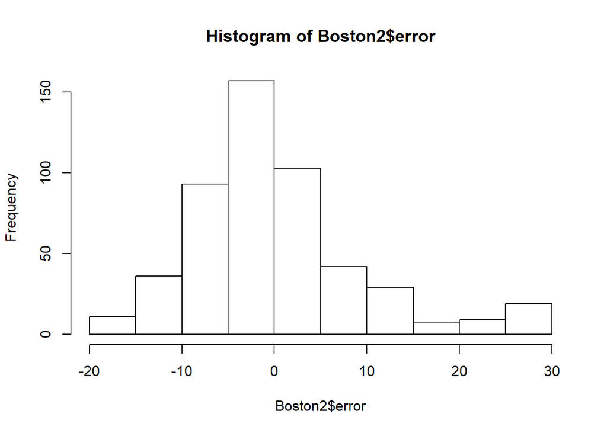

```r
library(dplyr)
## Predict housing price.
## Best initial prediction?
Boston2 <-
  Boston %>%
  mutate(avg_value=mean(medv))
## How much error is there in this prediction?
Boston2 <-
  Boston2 %>%
  mutate(error=medv-avg_value)
hist(Boston2$error)
```

```r
## Squared errors
Boston2 <-
  Boston2 %>%
  mutate(squareError=(medv-avg_value)^2)
## Mean squared error
Boston2 %>%
  summarize(MeanSquareError=mean((medv-avg_value)^2))
```

```
##   MeanSquareError
## 1        84.41956
```

# Correlated Predictors

- Some models may have issues with highly correlated predictors. We can check pairwise for highly correlated predictors.
- This can cause issues in some models, while others are robust to clustered data. If we have some convergence issues with models later on, we might check back on these correlated predictors.

```r
library(caret)
## Find highly correlated predictors
cor_mat <-
  cor(Boston)
findCorrelation(cor_mat,cutoff = 0.75,verbose = T)
```

```
## Compare row 3  and column  5 with corr  0.764
##   Means:  0.512 vs 0.387 so flagging column 3
## Compare row 10  and column  9 with corr  0.91
##   Means:  0.48 vs 0.369 so flagging column 10
## Compare row 5  and column  8 with corr  0.769
##   Means:  0.457 vs 0.35 so flagging column 5
## All correlations <= 0.75
```

```
## [1]  3 10  5
```

```r
rownames(cor_mat)[10]
```

```
## [1] "tax"
```

```r
colnames(cor_mat)[9]
```

```
## [1] "rad"
```

# Training and Test Sets

- The next step should be to split the data into a training and a test set, so we can evaluate the final model on the hold out (or test) set.

```r
## split into test and training sets
set.seed(3)
trainIndex <- createDataPartition(Boston$medv, p = .8,
                                  list = FALSE,
                                  times = 1)
BostonTrain <- Boston[trainIndex,]
BostonTest  <- Boston[-trainIndex,]
```

# Linear Regression

- Simple linear regression is the easiest model we can start with for this data. We are presuming a linear relationship for all continuous variables with no interactions.
- We can request that all of the variables are used in the model with the period.
- Can you write out the model that is being fit here?

```r
## Linear regression
mod_lin <- train(medv~.,
                 data=BostonTrain,
                 method = "lm",
                 metric="RMSE")
summary(mod_lin)
```

```
##
## Call:
## lm(formula = .outcome ~ ., data = dat)
##
## Residuals:
##      Min       1Q   Median       3Q      Max
## -16.8355  -2.7355  -0.7039   1.6733  27.3726
##
## Coefficients:
##               Estimate Std. Error t value Pr(>|t|)
## (Intercept)  32.552918   6.003179   5.423 1.03e-07 ***
## crim         -0.106893   0.035300  -3.028 0.002623 **
## zn            0.053127   0.015580   3.410 0.000717 ***
## indus         0.057361   0.067901   0.845 0.398756
## chas          3.076908   1.009121   3.049 0.002451 **
## nox         -18.450443   4.488075  -4.111 4.80e-05 ***
## rm            4.319682   0.507489   8.512 3.66e-16 ***
## age          -0.002509   0.015070  -0.166 0.867887
## dis          -1.453553   0.228227  -6.369 5.32e-10 ***
## rad           0.284776   0.075737   3.760 0.000196 ***
## tax          -0.012160   0.004218  -2.883 0.004157 **
## ptratio      -0.890908   0.147556  -6.038 3.62e-09 ***
## black         0.007537   0.003181   2.370 0.018294 *
## lstat        -0.505885   0.061190  -8.267 2.13e-15 ***
## ---
## Signif. codes:  0 '***' 0.001 '**' 0.01 '*' 0.05 '.' 0.1 ' ' 1
##
## Residual standard error: 4.799 on 393 degrees of freedom
## Multiple R-squared:  0.7446, Adjusted R-squared:  0.7362
## F-statistic: 88.14 on 13 and 393 DF,  p-value: < 2.2e-16
```

```r
mod_lin
```

```
## Linear Regression
##
## 407 samples
##  13 predictor
##
## No pre-processing
## Resampling: Bootstrapped (25 reps)
## Summary of sample sizes: 407, 407, 407, 407, 407, 407, ...
## Resampling results:
##
##   RMSE      Rsquared   MAE
##   5.088144  0.7171151  3.454128
##
## Tuning parameter 'intercept' was held constant at a value of TRUE
```

# Regularized Linear Regression

- The next family of models we will consider are called regularized linear regression.
- This includes LASSO, Elastic Net, and Ridge regression.
- These are penalized forms of a regular linear regression (like a logistic regression).
- The basic idea is that we can place a penalty on the estimated coefficients from the general linear model, ‘pushing’ them towards zero.
- If the coefficients are related to the outcome, they will ‘push’ back against our penalty.
- The stronger the relationship (or the stronger the predictor), the stronger they will ‘push’ back.
- The overall effect is that the coefficients are all shrunk towards zero. If the variable is not strongly related to the outcome, it will be shrunk close to zero, or possibly all the way to zero.
- This can give us effective variable selection, where the weak variables are eliminated since their coefficients are shrunk all the way to zero.
- Depending on how we apply the penalty, variables will either be shrunk all the way to zero (this is called the LASSO), or they will be shrunk to a small number, but still above zero (This is called ridge regression).
- We can also apply a mixture of the two penalties, which is called the elastic net regression.
- A natural question you might ask is, how do I pick the best model?
  - LASSO?
  - Ridge regression?
  - Elastic net (the mixture of the two)?
- Also, how strong of a penalty should I pick?
  - A very weak penalty, so it is essential just a logistic regression?
  - A very strong penalty, so almost all the coefficients are equal to zero?
  - Maybe something in between?

# Regularized Linear Regression: Elastic Net

- We will use an implementation in the R package `glmnet`, which was written by the authors who originally proposed the elastic net!
- In this implementation, there are two different parameters we can pass into the model.
  - Lambda: this is the strength of the penalty. It should be a positive number. Small values very close to 0 represent a weak penalty, which is essentially the underlying general linear model. Larger values will penalize the coefficients to be closer to zero.
  - Alpha: this is the mixing parameter. For Alpha == 1, it will fit a LASSO model. For Alpha == 0, it will fit a ridge regression. For an alpha in between, we will get an ‘elastic net’ model.
- For this implementation, the underlying routine will pick a range of lambdas for us, and fit the model across the entire range of lambdas.
- Just to give you an idea visually of what is going on with this model, let’s fit a few models and plot the result. I will pass in a value of 0 for alpha first, giving us a ridge regression.
- I will use the glmnet package first. It does not accept the formula style input, so we have to actually create the model matrices and pass them in.

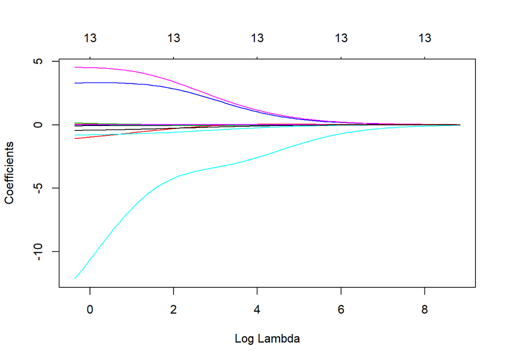

```r
library(glmnet)
## establish matrices
X = model.matrix(~.-medv-1,
                 data=BostonTrain)
Y = BostonTrain$medv
## fit model
mod_glm <- glmnet(x = X,
                  y=Y,
                  alpha = 0)
## Explore results
plot(mod_glm,xvar = 'lambda')
```

```r
## Coefficient for lambda = 0
coef(mod_glm,s=0)
```

```
## 14 x 1 sparse Matrix of class "dgCMatrix"
##                         1
## (Intercept)  24.204168988
## crim         -0.089199825
## zn            0.039032716
## indus        -0.004596400
## chas          3.280221316
## nox         -12.146141534
## rm            4.509459201
## age          -0.006155089
## dis          -1.083447450
## rad           0.135333263
## tax          -0.005744055
## ptratio      -0.816304471
## black         0.007517465
## lstat        -0.449804668
```

```r
## Coefficients for lambda = 1
coef(mod_glm,s=1)
```

```
## 14 x 1 sparse Matrix of class "dgCMatrix"
##                         1
## (Intercept)  22.485373035
## crim         -0.085327126
## zn            0.035832863
## indus        -0.015344031
## chas          3.300590269
## nox         -10.619673663
## rm            4.501814164
## age          -0.006721384
## dis          -0.976140452
## rad           0.108592461
## tax          -0.004827464
## ptratio      -0.795945987
## black         0.007464008
## lstat        -0.432713207
```

- We could also try out a LASSO, by putting in a value of 1 for alpha.

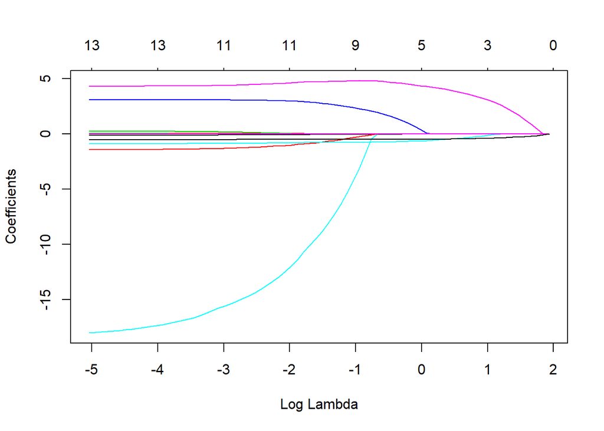

```r
## fit model
mod_glmnet <- glmnet(x = X,
                  y=Y,
                  alpha = 1)
## Explore results
plot(mod_glmnet,xvar = 'lambda')
```

```r
## Coefficient for lambda = 0
coef(mod_glmnet,s=0)
```

```
## 14 x 1 sparse Matrix of class "dgCMatrix"
##                         1
## (Intercept)  32.003893872
## crim         -0.104889377
## zn            0.051906881
## indus         0.047702064
## chas          3.081897972
## nox         -18.026384486
## rm            4.330693512
## age          -0.002111971
## dis          -1.433300757
## rad           0.269508599
## tax          -0.011382518
## ptratio      -0.884866116
## black         0.007437959
## lstat        -0.505389102
```

```r
## Coefficients for lambda = 1
coef(mod_glmnet,s=1)
```

```
## 14 x 1 sparse Matrix of class "dgCMatrix"
##                         1
## (Intercept) 12.3887080889
## crim         .
## zn           .
## indus        .
## chas         0.3690872685
## nox          .
## rm           4.3639419746
## age          .
## dis          .
## rad          .
## tax          .
## ptratio     -0.6192803604
## black        0.0004435658
## lstat       -0.4855519873
```

- But how do we know which value is best?!?

# Caret and the Elastic Net

- We can use Caret to fit the model, taking advantage of the common syntax from the `train` function.
- The authors of caret have gone to the trouble of identifying what parameters are needed to optimize for a wide range of machine learning classification models.
- In the case of glmnet (elastic net), we just saw that we need to decide on two parameters:
  - Alpha
  - lambda
- If we simply call the caret train function, we will see that the authors have populated a reasonable range of values for these parameters.
- The train function will fit models using a combination of different parameters, then tell us how each one has performed.
- There are more details to be explored on how caret is deciding which model is best, but we will get to that shortly.
- Let’s fit a model first, using the defaults.

```r
## Use caret to fit this model
mod_glmnet <-
  train(medv~.,
        data=BostonTrain,
        method='glmnet',
        metric="RMSE")
mod_glmnet
```

```
## glmnet
##
## 407 samples
##  13 predictor
##
## No pre-processing
## Resampling: Bootstrapped (25 reps)
## Summary of sample sizes: 407, 407, 407, 407, 407, 407, ...
## Resampling results across tuning parameters:
##
##   alpha  lambda      RMSE      Rsquared   MAE
##   0.10   0.01385319  4.934767  0.7202446  3.423419
##   0.10   0.13853188  4.924573  0.7205907  3.392837
##   0.10   1.38531882  5.011618  0.7113853  3.381633
##   0.55   0.01385319  4.935112  0.7201834  3.422491
##   0.55   0.13853188  4.951546  0.7169945  3.392189
##   0.55   1.38531882  5.275304  0.6874857  3.603388
##   1.00   0.01385319  4.935438  0.7200511  3.419579
##   1.00   0.13853188  4.985141  0.7128136  3.404042
##   1.00   1.38531882  5.462160  0.6780189  3.754972
##
## RMSE was used to select the optimal model using the smallest value.
## The final values used for the model were alpha = 0.1 and lambda = 0.1385319.
```

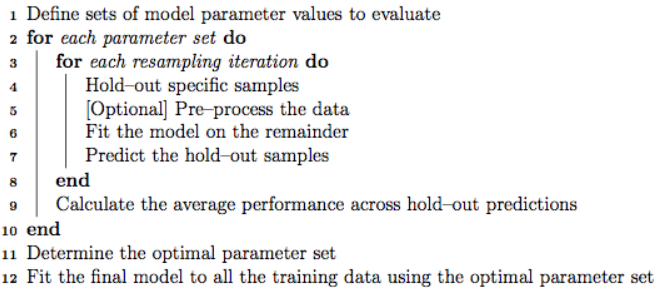

# Model Validation

```r
## Set control parameters
ctrl <- trainControl(method = "repeatedcv",
                     repeats = 3,
                     number=10,
                     savePred=T)
## Use caret to fit this model
mod_glmnet <-
  train(medv~.,
        data=BostonTrain,
        method='glmnet',
        trControl = ctrl,
        metric="RMSE")
mod_glmnet
```

```
## glmnet
##
## 407 samples
##  13 predictor
##
## No pre-processing
## Resampling: Cross-Validated (10 fold, repeated 3 times)
## Summary of sample sizes: 366, 367, 365, 367, 367, 366, ...
## Resampling results across tuning parameters:
##
##   alpha  lambda      RMSE      Rsquared   MAE
##   0.10   0.01385319  4.829135  0.7375247  3.361232
##   0.10   0.13853188  4.825154  0.7375830  3.331822
##   0.10   1.38531882  4.980143  0.7240943  3.362375
##   0.55   0.01385319  4.828637  0.7375960  3.359674
##   0.55   0.13853188  4.845081  0.7355665  3.317869
##   0.55   1.38531882  5.294590  0.6989333  3.618166
##   1.00   0.01385319  4.827655  0.7376581  3.355543
##   1.00   0.13853188  4.906511  0.7290648  3.341012
##   1.00   1.38531882  5.473431  0.6935655  3.770396
##
## RMSE was used to select the optimal model using the smallest value.
## The final values used for the model were alpha = 0.1 and lambda = 0.1385319.
```

# Comparing Models

```r
## Set control parameters
ctrl <- trainControl(method = "repeatedcv",
                     repeats = 3,
                     number=10,
                     savePred=T)
## Linear regression
mod_lin <- train(medv~.,
                 data=BostonTrain,
                 method = "lm",
                 metric="RMSE",
                 trControl=ctrl)
summary(mod_lin)
```

```
##
## Call:
## lm(formula = .outcome ~ ., data = dat)
##
## Residuals:
##      Min       1Q   Median       3Q      Max
## -16.8355  -2.7355  -0.7039   1.6733  27.3726
##
## Coefficients:
##               Estimate Std. Error t value Pr(>|t|)
## (Intercept)  32.552918   6.003179   5.423 1.03e-07 ***
## crim         -0.106893   0.035300  -3.028 0.002623 **
## zn            0.053127   0.015580   3.410 0.000717 ***
## indus         0.057361   0.067901   0.845 0.398756
## chas          3.076908   1.009121   3.049 0.002451 **
## nox         -18.450443   4.488075  -4.111 4.80e-05 ***
## rm            4.319682   0.507489   8.512 3.66e-16 ***
## age          -0.002509   0.015070  -0.166 0.867887
## dis          -1.453553   0.228227  -6.369 5.32e-10 ***
## rad           0.284776   0.075737   3.760 0.000196 ***
## tax          -0.012160   0.004218  -2.883 0.004157 **
## ptratio      -0.890908   0.147556  -6.038 3.62e-09 ***
## black         0.007537   0.003181   2.370 0.018294 *
## lstat        -0.505885   0.061190  -8.267 2.13e-15 ***
## ---
## Signif. codes:  0 '***' 0.001 '**' 0.01 '*' 0.05 '.' 0.1 ' ' 1
##
## Residual standard error: 4.799 on 393 degrees of freedom
## Multiple R-squared:  0.7446, Adjusted R-squared:  0.7362
## F-statistic: 88.14 on 13 and 393 DF,  p-value: < 2.2e-16
```

```r
mod_lin
```

```
## Linear Regression
##
## 407 samples
##  13 predictor
##
## No pre-processing
## Resampling: Cross-Validated (10 fold, repeated 3 times)
## Summary of sample sizes: 366, 365, 367, 367, 367, 366, ...
## Resampling results:
##
##   RMSE      Rsquared   MAE
##   4.816084  0.7422885  3.395262
##
## Tuning parameter 'intercept' was held constant at a value of TRUE
```

- We can use the resamples function to compare the performance

```r
r1 <-
  resamples(list(glm=mod_lin,
                 glmnet=mod_glmnet))
summary(r1)
```

```
##
## Call:
## summary.resamples(object = r1)
##
## Models: glm, glmnet
## Number of resamples: 30
##
## MAE
##            Min.  1st Qu.   Median     Mean  3rd Qu.     Max. NA's
## glm    2.184700 2.887801 3.329239 3.395262 3.812275 5.134374    0
## glmnet 2.525662 3.048659 3.275857 3.331822 3.583690 4.439629    0
##
## RMSE
##            Min.  1st Qu.   Median     Mean  3rd Qu.     Max. NA's
## glm    3.018555 3.808990 4.679796 4.816084 5.734461 7.576005    0
## glmnet 3.211718 4.193276 4.745249 4.825154 5.378883 6.951357    0
##
## Rsquared
##             Min.   1st Qu.    Median      Mean   3rd Qu.      Max. NA's
## glm    0.4613866 0.7091195 0.7403999 0.7422885 0.8159068 0.8924565    0
## glmnet 0.5619791 0.6717730 0.7480843 0.7375830 0.8039110 0.8693092    0
```

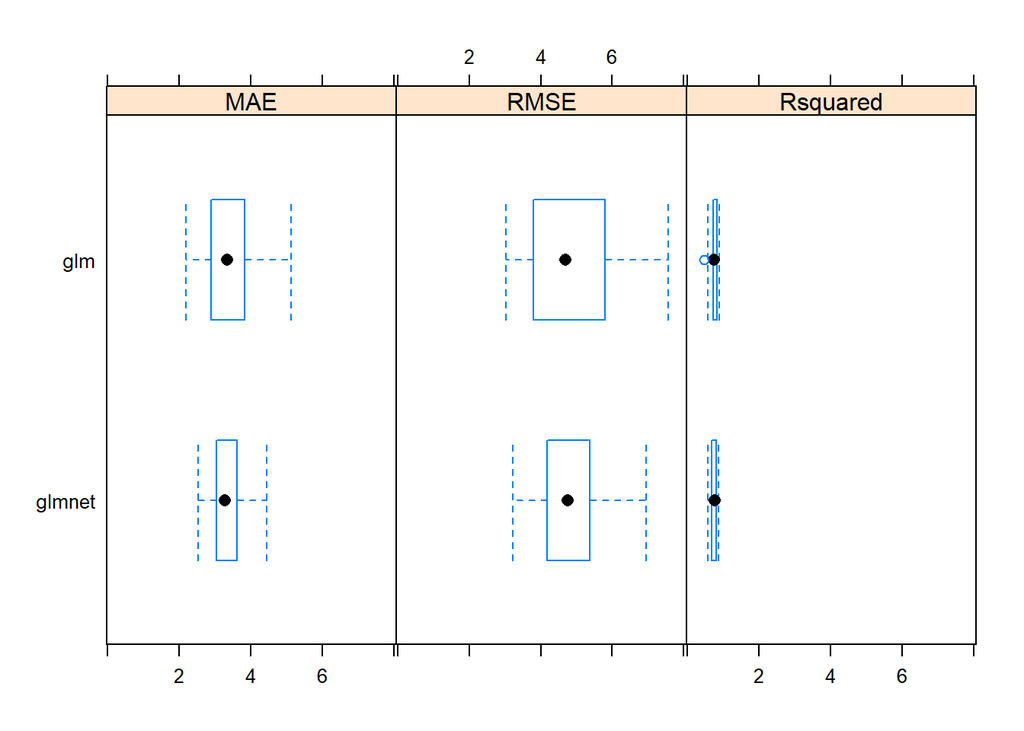

```r
bwplot(r1)
```

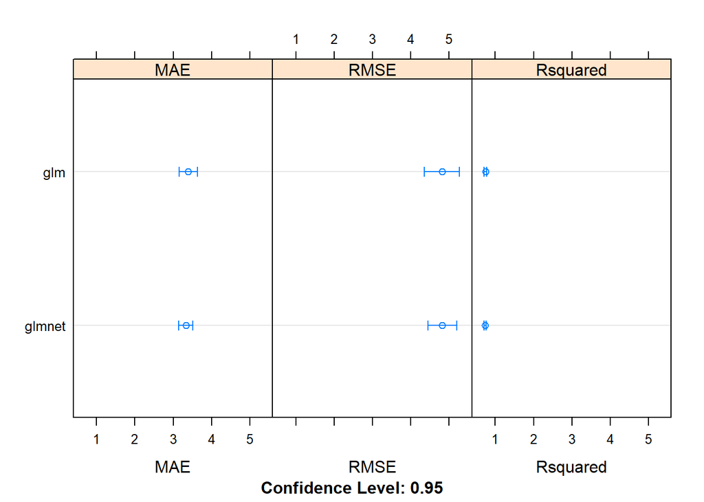

```r
dotplot(r1)
```

- It looks like there is not much difference in these models.

# Other algorithms

- Caret has implemented over 200 models, all easily accessible via the caret train interface.
- Check out the caret help [page](http://topepo.github.io/caret/) to review all the different models that are available.
- The train function will construct a reasonable range of hyperparameters for a given model, then implement a model validation technique as shown above, then report back the optimal hyperparameters.
- Let’s fit a few more classification techniques, and see how they perform compared with the glm or glmnet.

# Robust Linear Model

- There is a form of a linear regression called ‘robust linear regression’, which uses an M-estimator.
- This model uses an M-estimator (rather than ordinary least squares) for optimization. This estimator is robust to outliers and extreme values. It may give us a better fit here if the data has some odd outliers that are heavily influencing the overall fit.
- Here is a [link](http://www.stats.ox.ac.uk/pub/StatMeth/Robust.pdf) with more information if you are interested.

```r
modelLookup('rlm')
```

```
##   model parameter     label forReg forClass probModel
## 1   rlm intercept intercept   TRUE    FALSE     FALSE
## 2   rlm       psi       psi   TRUE    FALSE     FALSE
```

```r
mod_rlin <- train(medv~.,
                 data=BostonTrain,
                 method = "rlm",
                 trControl = ctrl,
                 metric="RMSE")
summary(mod_rlin)
```

```
##
## Call: rlm(formula = .outcome ~ ., data = dat, psi = psi)
## Residuals:
##      Min       1Q   Median       3Q      Max
## -16.3609  -1.8472  -0.3668   2.0621  33.5322
##
## Coefficients:
##             Value   Std. Error t value
## (Intercept) 13.6840  4.1919     3.2644
## crim        -0.1131  0.0246    -4.5875
## zn           0.0434  0.0109     3.9862
## indus        0.0185  0.0474     0.3903
## chas         2.0903  0.7047     2.9664
## nox         -9.1155  3.1339    -2.9086
## rm           5.5936  0.3544    15.7847
## age         -0.0290  0.0105    -2.7552
## dis         -1.0979  0.1594    -6.8895
## rad          0.1777  0.0529     3.3593
## tax         -0.0111  0.0029    -3.7735
## ptratio     -0.7115  0.1030    -6.9051
## black        0.0102  0.0022     4.6020
## lstat       -0.3104  0.0427    -7.2646
##
## Residual standard error: 2.872 on 393 degrees of freedom
```

```r
mod_rlin
```

```
## Robust Linear Model
##
## 407 samples
##  13 predictor
##
## No pre-processing
## Resampling: Cross-Validated (10 fold, repeated 3 times)
## Summary of sample sizes: 366, 366, 366, 367, 365, 367, ...
## Resampling results across tuning parameters:
##
##   intercept  psi           RMSE      Rsquared   MAE
##   FALSE      psi.huber     4.902186  0.7289930  3.194201
##   FALSE      psi.hampel    4.921220  0.7259231  3.221218
##   FALSE      psi.bisquare  4.956472  0.7250481  3.186815
##    TRUE      psi.huber     4.857803  0.7355581  3.214601
##    TRUE      psi.hampel    4.878775  0.7310398  3.239918
##    TRUE      psi.bisquare  4.977632  0.7275651  3.207968
##
## RMSE was used to select the optimal model using the smallest value.
## The final values used for the model were intercept = TRUE and psi = psi.huber.
```

# Least Angle regression

- Least angle regression is another potential form of optimization to use in regression.

```r
## LARS
mod_lars <- train(medv~.,
                 data=BostonTrain,
                 method = 'lars',
                 trControl = ctrl,
                 metric="RMSE")
mod_lars
```

```
## Least Angle Regression
##
## 407 samples
##  13 predictor
##
## No pre-processing
## Resampling: Cross-Validated (10 fold, repeated 3 times)
## Summary of sample sizes: 367, 367, 367, 365, 366, 366, ...
## Resampling results across tuning parameters:
##
##   fraction  RMSE      Rsquared   MAE
##   0.050     8.512069  0.6057159  6.077611
##   0.525     5.042679  0.7132226  3.429898
##   1.000     4.848486  0.7308503  3.394220
##
## RMSE was used to select the optimal model using the smallest value.
## The final value used for the model was fraction = 1.
```

```r
summary(mod_lars)
```

```
## LARS/LASSO
## Call: lars::lars(x = as.matrix(x), y = y)
##    Df   Rss       Cp
## 0   1 35442 1133.833
## 1   2 31822  978.650
## 2   3 17119  342.282
## 3   4 11835  114.865
## 4   5 11711  111.466
## 5   6 11493  104.019
## 6   7 10735   73.095
## 7   8 10671   72.318
## 8   9 10265   56.710
## 9  10  9555   27.869
## 10 11  9523   28.472
## 11 12  9106   12.349
## 12 13  9085   13.458
## 13 14  9051   14.000
```

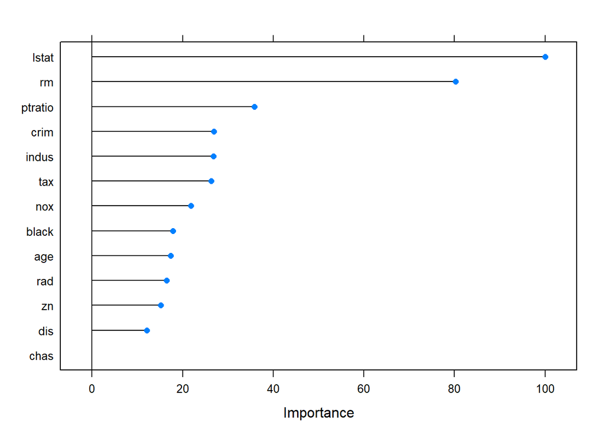

```r
plot(varImp(mod_lars))
```

# Regression: Support Vector Machine

- A support Vector machine is another popular framework for doing regression. This model is easily implemented in Caret.

```r
## SVM
mod_svm <- train(medv~.,
                 data=BostonTrain,
                 method = 'svmLinear',
                 trControl = ctrl,
                 metric="RMSE")
mod_svm
```

```
## Support Vector Machines with Linear Kernel
##
## 407 samples
##  13 predictor
##
## No pre-processing
## Resampling: Cross-Validated (10 fold, repeated 3 times)
## Summary of sample sizes: 367, 366, 366, 367, 365, 366, ...
## Resampling results:
##
##   RMSE      Rsquared   MAE
##   4.937513  0.7298979  3.200696
##
## Tuning parameter 'C' was held constant at a value of 1
```

# Random Forest

- A popular classification algorithm is the random forest. This can also be used for regression.
- In order to understand a random forest, you should first think about a decision tree.
- We can consider modeling data simply by making cutpoints on our predictors, then splitting the decision of the outcome.
- Visually, that might look like this in the context of our data:
- If age < 40, deny credit card
- If age > 40, then:
  - If income > 5, accept credit card
  - If income < 5, accept credit card
- Decision trees have a very nice appeal in that they are easy to understand and visualize. You can simply make a score card, and a human could easily make a decision on whether the outcome is yes or no.
- But they are not very accurate or flexible individually! How can we have a good model from a single decision tree? It seems unlikely.
- But what if we created many different decision trees, based on different subsets of the data?
- We could take random samples of the data, then get an optimal decision tree using a subset of the predictors for each sample.
- Each individual tree isn’t that great, but perhaps the population of all those trees (the ensemble) would be good?
- That is the intuition behind a random forest!
- We can easily implement a random forest using caret, which in turn uses the underlying randomForest package. - The only tuning parameter is mtry, which is the number of predictors selected for each tree.

```r
## SVM
mod_rf <- train(medv~.,
                data=BostonTrain,
                method = 'rf',
                trControl = ctrl,
                metric="RMSE")
mod_rf
```

```
## Random Forest
##
## 407 samples
##  13 predictor
##
## No pre-processing
## Resampling: Cross-Validated (10 fold, repeated 3 times)
## Summary of sample sizes: 367, 366, 367, 366, 365, 367, ...
## Resampling results across tuning parameters:
##
##   mtry  RMSE      Rsquared   MAE
##    2    3.566312  0.8703804  2.421751
##    7    3.177687  0.8911471  2.183565
##   13    3.193960  0.8874671  2.213219
##
## RMSE was used to select the optimal model using the smallest value.
## The final value used for the model was mtry = 7.
```

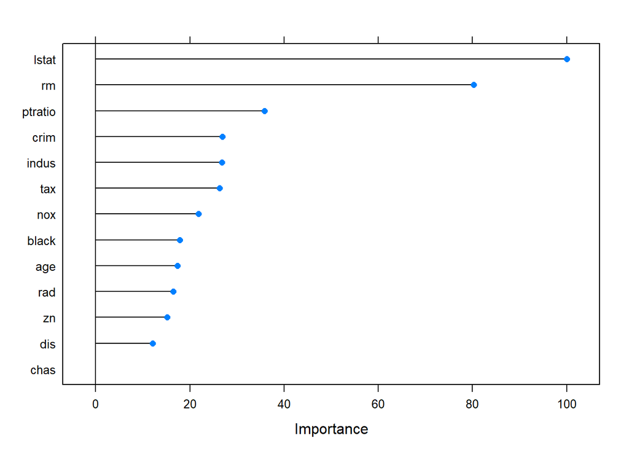

```r
plot(varImp(mod_lars))
```

# Compare These Models

- We can compare the distributions of either RMSE or R-squared values across resamples of these different models
- This will allow us to pick the best model, and get a sense of how really different they are in terms of their error.

```r
## Resample algorithms for comparison
r2 <- resamples(list(lars = mod_lars,
                     lin = mod_lin,
                     rlin = mod_rlin,
                     svm = mod_svm,
                     glmnet = mod_glmnet,
                     rf = mod_rf))
## Examine results
summary(r2)
```

```
##
## Call:
## summary.resamples(object = r2)
##
## Models: lars, lin, rlin, svm, glmnet, rf
## Number of resamples: 30
##
## MAE
##            Min.  1st Qu.   Median     Mean  3rd Qu.     Max. NA's
## lars   2.184354 2.967878 3.561933 3.394220 3.792244 4.054734    0
## lin    2.184700 2.887801 3.329239 3.395262 3.812275 5.134374    0
## rlin   2.312897 2.766927 3.177791 3.214601 3.474696 4.546025    0
## svm    1.881537 2.835092 3.130211 3.200696 3.621924 4.435620    0
## glmnet 2.525662 3.048659 3.275857 3.331822 3.583690 4.439629    0
## rf     1.648678 1.915175 2.079206 2.183565 2.391825 3.022714    0
##
## RMSE
##            Min.  1st Qu.   Median     Mean  3rd Qu.     Max. NA's
## lars   2.832295 3.925188 4.860244 4.848486 5.642694 6.484806    0
## lin    3.018555 3.808990 4.679796 4.816084 5.734461 7.576005    0
## rlin   2.836872 3.871067 4.439287 4.857803 5.697367 8.107487    0
## svm    2.424379 3.976289 4.631297 4.937513 5.928246 7.369053    0
## glmnet 3.211718 4.193276 4.745249 4.825154 5.378883 6.951357    0
## rf     2.068716 2.564396 2.926205 3.177687 3.768832 4.672248    0
##
## Rsquared
##             Min.   1st Qu.    Median      Mean   3rd Qu.      Max. NA's
## lars   0.5359242 0.6520248 0.7294491 0.7308503 0.8190320 0.9004227    0
## lin    0.4613866 0.7091195 0.7403999 0.7422885 0.8159068 0.8924565    0
## rlin   0.4132484 0.7240518 0.7727191 0.7355581 0.8216434 0.8796599    0
## svm    0.4541734 0.6501328 0.7432723 0.7298979 0.8048493 0.8981926    0
## glmnet 0.5619791 0.6717730 0.7480843 0.7375830 0.8039110 0.8693092    0
## rf     0.8032245 0.8600829 0.8931831 0.8911471 0.9252489 0.9534995    0
```

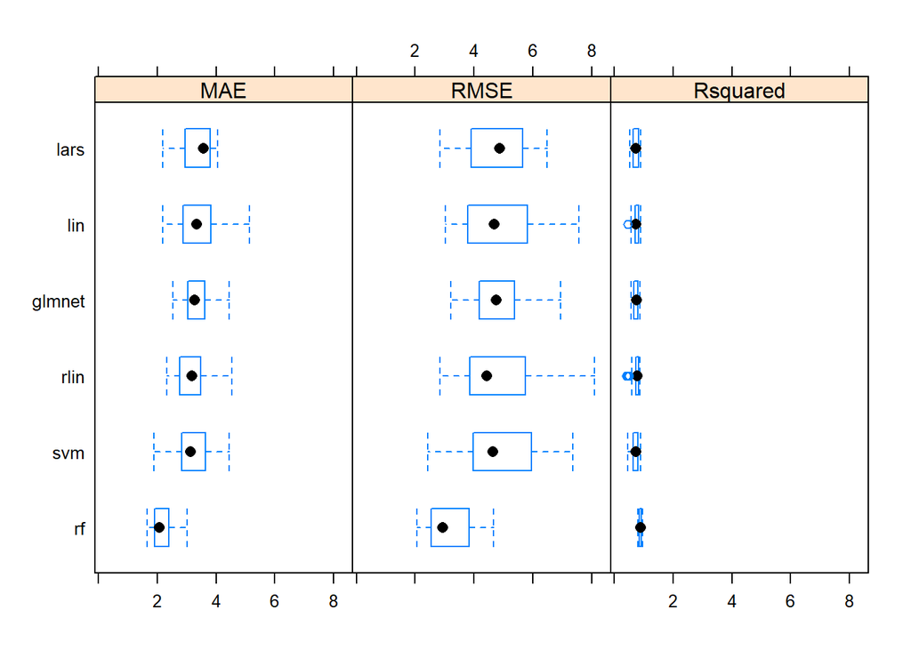

```r
bwplot(r2)
```

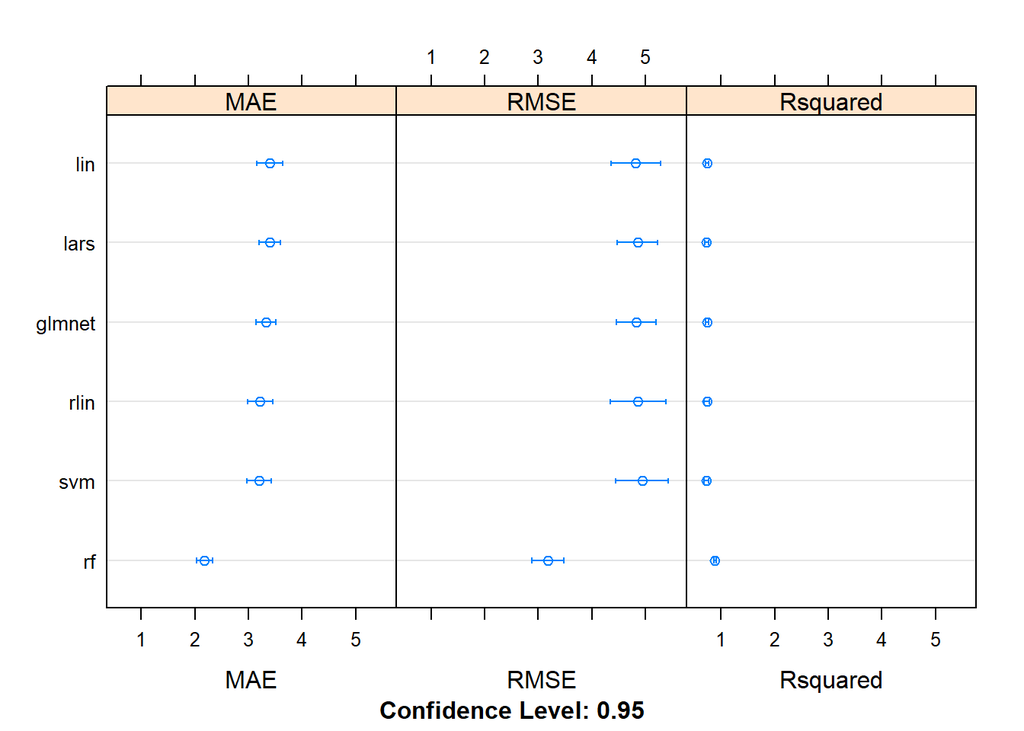

```r
dotplot(r2)
```

# Score Final Model on Test Data

- Now we have completed predictive modeling based on the training data, lets see if its actually any good on our hold-out sample.
- For regression, we can use the `postResample` function to calculate R squared and MSE on the testing data.
- We will need to use the model to make predictions, then call the `postResample` function.
- Prior to any optimization, we split the data to see if we were over-fitting the sub-sample.

```r
## Pick best model - mod_rf
## Score testing data
b_test_pred <- predict(mod_rf,BostonTest)
postResample(b_test_pred, BostonTest$medv)
```

```
##      RMSE  Rsquared       MAE
## 3.2426077 0.8691583 2.3062140
```